# Week 3?

# Two Puzzles

## Puzzle 1

- Dillon and Wagers (2019) conducted a yes/no acceptability judgement experiment including experimental conditions like (1a).
- Almost untimed, timeout after 10 seconds.
- The acceptability rates for (1a) and (1b) were 18.4% and 87.1%, respectively?
- This means that the error rates were 18.4% and 12.9%

(1a) *Who do you think that the new professor is going to persuade anyone?

(1b) Who thinks that the new professor is going to persuade anyone?

- Why are there errors? This is a pretty simple task.
- Why do the error rates differ?

## Puzzle 2

- Swets et al. (2008) had participants read sentences like (2a,b,c), with N1, N2 or ambiguous attachment, and asked comprehension questions like (3).

(2a) The **maid$_{N1}$** of the **princess$_{N2}$** $[$who scratched herself in public$]$ was terribly humiliated.

(2b) The **son** of the princess$_{N2}$ $[$who scratched himself in public$]$ was terribly humiliated.

(2c) The son$_{N1}$ of the **princess$_{N2}$** $[$who scratched herself in public$]$ was terribly humiliated.

3. Question: Did the maid/princess/son scratch in public?

```r
library(dplyr)
```

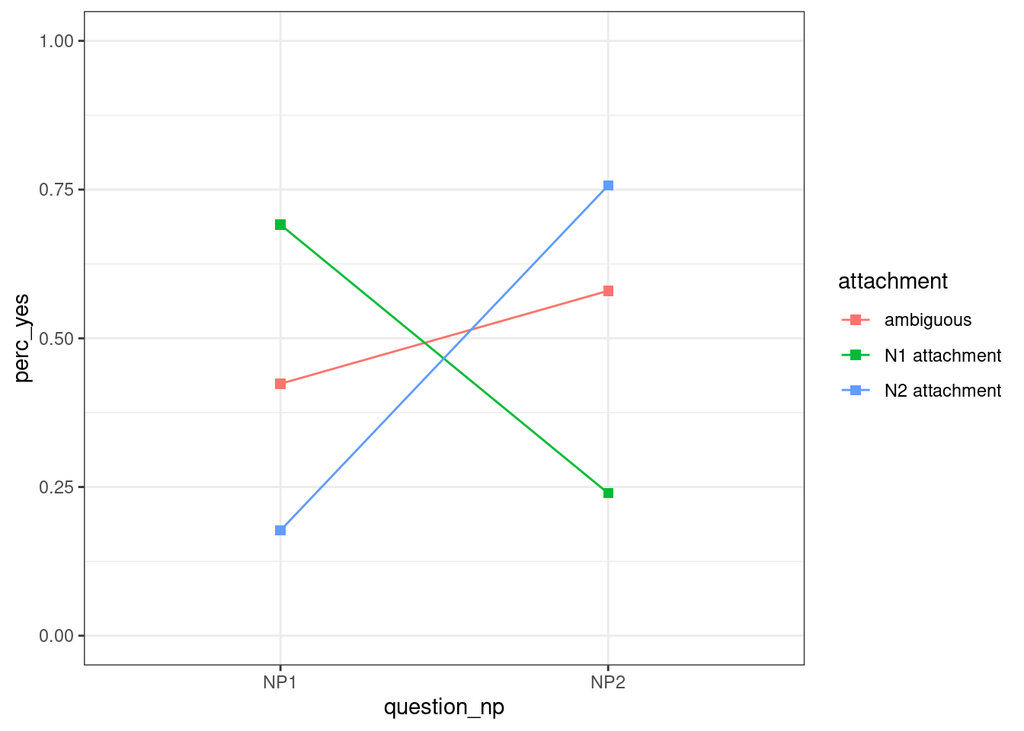

```r
library(magrittr)
library(ggplot2)

options(dplyr.summarise.inform = FALSE)

df <- read.csv("https://raw.githubusercontent.com/plogacev/manuscript_LogacevVasishth_CogSci_SMCM/master/data_original/Data_Swets_et_al/Data_All.csv", sep=";", as.is=T)
question_responses_en <- df %>% dplyr::select(-the:-w18)

id_cols <- c("subject","item","trial","X1","response_yes","response_RT","response_correct","qtype","attachment","question_np")
colnames(question_responses_en)[1:10] <- id_cols

question_responses_en$qtype %<>% dplyr::recode("1"="RC questions","2"="superficial","3"="occasional")
question_responses_en$attachment %<>% dplyr::recode("1"="ambiguous","2"="N1 attachment","3"="N2 attachment")
question_responses_en$response_yes %<>% as.character %>% dplyr::recode("1"=1,"2"=0)
question_responses_en$question_np %<>% dplyr::recode("1"="NP1","2"="NP2")

question_responses_en %<>% subset(qtype == "RC questions")


question_responses_n_en <-
  question_responses_en %>% group_by(subject,attachment, question_np) %>%
  dplyr::summarise( n_yes = sum(response_yes),
                    n = n(),
                    n_n1 = ifelse(question_np[1] == "NP1", n_yes, n-n_yes),
                    perc_yes = n_yes/n
                  )
question_responses_n_en %<>% left_join( data.frame(question_np = c("NP1", "NP2"), probe_n1 = c(1, 0)), by = "question_np" )
question_responses_n_en %<>% left_join( data.frame(attachment = c("ambiguous", "N2 attachment", "N1 attachment"), condition_id = c(3, 2, 1)), by = "attachment"  )


question_responses_n_summary_en <-
  question_responses_n_en %>% group_by(attachment, question_np) %>%
  dplyr::summarise( perc_yes = mean(perc_yes) )


question_responses_n_summary_en %>% ggplot(aes(question_np, perc_yes, color = attachment, group = attachment)) +
  geom_point(shape = "square", size = 2) + geom_line() + theme_bw() + scale_y_continuous(limits = c(0,1))
```

```r
# question_responses_n_summary_en_unamb <- question_responses_n_summary_en %>% subset(attachment != "ambiguous")
# question_responses_n_summary_en_unamb %<>% mutate(perc_correct =
#                                                    ifelse(attachment == "N1 attachment",
#                                                           ifelse(question_np == "NP1", perc_yes, 1-perc_yes),
#                                                           ifelse(question_np == "NP1", 1-perc_yes, perc_yes)) )

  # question_responses_n_summary_en_unamb %>%
  #   ggplot(aes(question_np, perc_correct, color = attachment, group = attachment)) +
  #   geom_point(shape = "square", size = 2) + geom_line() + theme_bw() + scale_y_continuous(limits = c(0,1))
```

- Why are there errors? This task is also not hard.
- Why do the error rates differ again

## Conclusion

- Ideally, we’d like to understand why errors happen. (e.g., diffusion model or something more specific)
- If we can’t (or don’t want to), we can at least try to account for them and some of their properties. (MPTs)

# A first example of errors in grammaticality judgements

- Let’s model the the Dillon and Wagers (2019) phenomenon in the form of a multinomial processing tree model.

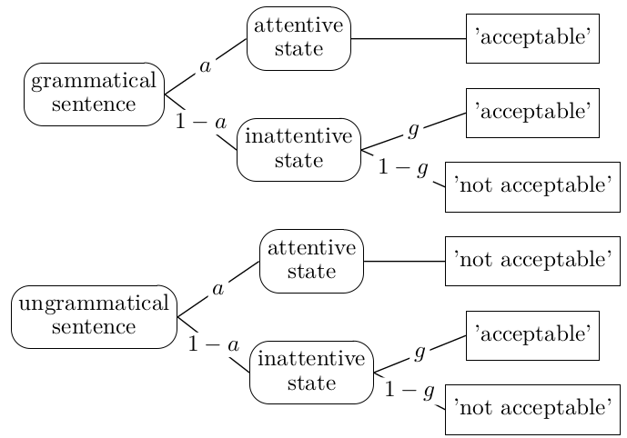

$$P_{Y,G} = a \cdot 1 + (1-a)\cdot g$$

$$P_{N,G} = (1-a)\cdot(1-g)$$

$$P_{Y,U} = (1-a)\cdot g$$

$$P_{N,U} = a + (1-a)\cdot (1-g)$$

- Let’s write down the probabilities of ‘acceptable’ and ‘unacceptable’ responses by condition,

```r
prob_yes_gram <- function(a, g) {
  a + (1-a)*g
}
prob_yes_ungram <- function(a, g) {
  (1-a)*g
}
```

- Let’s generate some data:

```r
generate_mpt_dataset <- function(n, a, g)
{
  # generate responses for gram condition
  prob_yes <- prob_yes_gram(a, g)
  n_yes_gram <- rbinom(n = 1, size = n, prob = prob_yes)

  # generate responses for ungram condition
  prob_yes <- prob_yes_ungram(a, g)
  n_yes_ungram <- rbinom(n = 1, size = n, prob = prob_yes)

  # return as data frame
  data.frame(condition = c("gram", "ungram"),
             n_yes = c(n_yes_gram, n_yes_ungram),
             n = n)
}


generate_mpt_dataset(n = 100, a=.5, g=.5)
```

| condition | n_yes | n |
| --- | --- | --- |
| gram | 69 | 100 |
| ungram | 24 | 100 |

- Let’s see what the model predicts. Can it generate any combination of error rates for two conditions?

```r
# Generate data for each combination of parameters

all_results <- data.frame()

for(cur_a in seq(0,1, .05)) {
    for(cur_g in seq(0,1, .05)) {
      dat <- generate_mpt_dataset(n = 10^4, a=cur_a, g=cur_g)
      dat$a <- cur_a
      dat$g <- cur_g
      all_results <- rbind(all_results, dat)
    }
}

head(all_results)
```

|  | condition | n_yes | n | a | g |
| --- | --- | --- | --- | --- | --- |
| 1 | gram | 0 | 10000 | 0 | 0.00 |
| 2 | ungram | 0 | 10000 | 0 | 0.00 |
| 3 | gram | 520 | 10000 | 0 | 0.05 |
| 4 | ungram | 501 | 10000 | 0 | 0.05 |
| 5 | gram | 1020 | 10000 | 0 | 0.10 |
| 6 | ungram | 1024 | 10000 | 0 | 0.10 |

```r
all_results %<>% mutate(p_yes = n_yes/n)

all_results_plot <- all_results %>% dplyr::select(a, g, p_yes, condition) %>% tidyr::pivot_wider(names_from = condition, values_from = p_yes)

head(all_results_plot)
```

| a | g | gram | ungram |
| --- | --- | --- | --- |
| 0 | 0.00 | 0.0000 | 0.0000 |
| 0 | 0.05 | 0.0520 | 0.0501 |
| 0 | 0.10 | 0.1020 | 0.1024 |
| 0 | 0.15 | 0.1514 | 0.1445 |
| 0 | 0.20 | 0.1984 | 0.2029 |
| 0 | 0.25 | 0.2499 | 0.2407 |

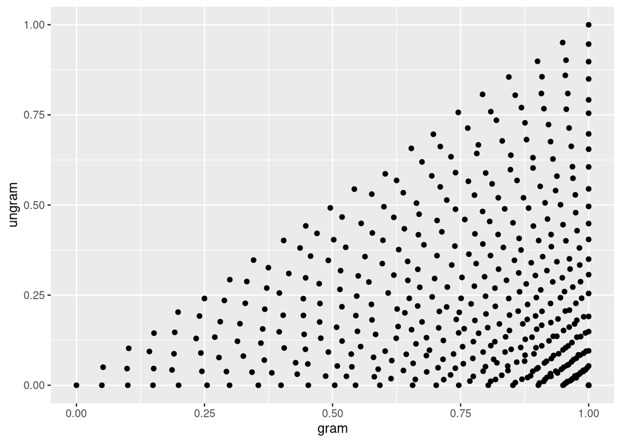

```r
ggplot(all_results_plot, aes(gram, ungram)) + geom_point()
```

- What if we knew parameter $a$? (For example, because we find a way of controlling it.)

```r
# Let's take a look at the receiver operating characteristic (ROC)

unique(all_results_plot$a)
```

```
##  [1] 0.00 0.05 0.10 0.15 0.20 0.25 0.30 0.35 0.40 0.45 0.50 0.55 0.60 0.65 0.70
## [16] 0.75 0.80 0.85 0.90 0.95 1.00
```

```r
results_a_070809 <- all_results_plot %>% subset(round(a,2) %in% c(0.70, 0.8, .9))
results_a_070809
```

| a | g | gram | ungram |
| --- | --- | --- | --- |
| 0.7 | 0.00 | 0.7024 | 0.0000 |
| 0.7 | 0.05 | 0.7171 | 0.0156 |
| 0.7 | 0.10 | 0.7304 | 0.0287 |
| 0.7 | 0.15 | 0.7397 | 0.0472 |
| 0.7 | 0.20 | 0.7553 | 0.0597 |
| 0.7 | 0.25 | 0.7739 | 0.0746 |
| 0.7 | 0.30 | 0.7940 | 0.0921 |
| 0.7 | 0.35 | 0.8090 | 0.1099 |
| 0.7 | 0.40 | 0.8169 | 0.1208 |
| 0.7 | 0.45 | 0.8379 | 0.1343 |

[output cut: 53 more lines]

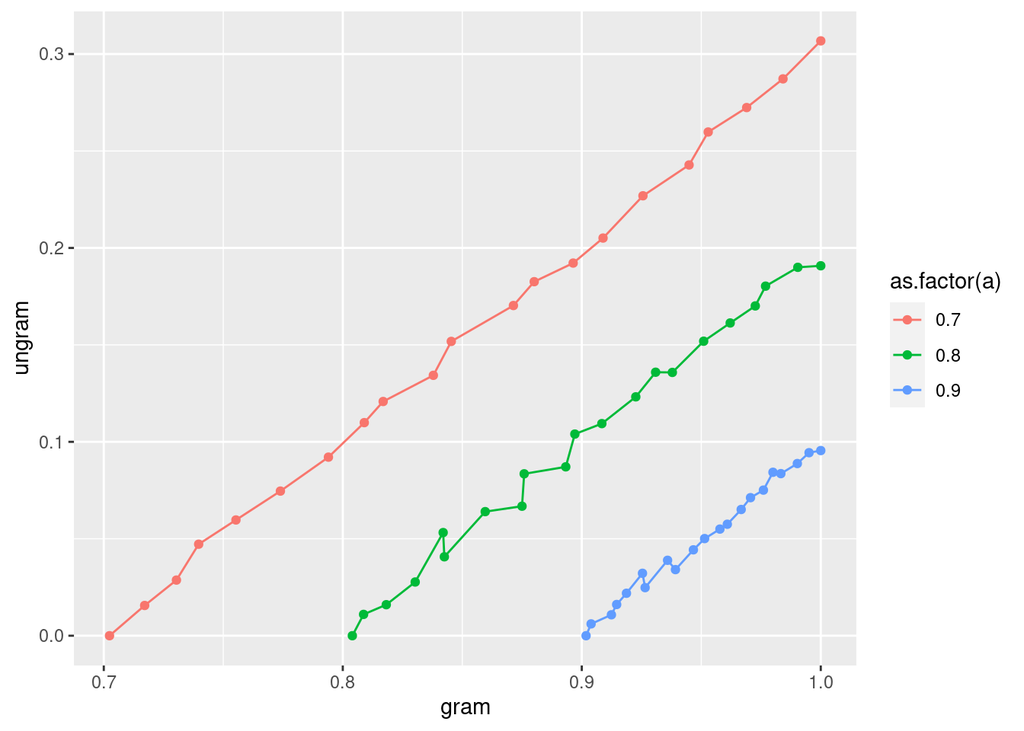

```r
ggplot(results_a_070809, aes(gram, ungram, color = as.factor(a) )) + geom_point() + geom_line()
```

```r
# Generate a data set with known parameters (a=.8, g=.4)
data_for_optimization <- all_results_plot %>% subset(round(a,2) == .8 & round(g,2) == .4)

# Let's implement an objective function ('discrepancy function')
# An objective function, reflects the 'badness of fit' of a model,
# by quantifying the devation of each prediction from every data point.
mpt_objective_function <- function(a, g) {
  dev_gram <- (data_for_optimization$gram - prob_yes_gram(a, g))
  dev_ungram <- (data_for_optimization$ungram - prob_yes_ungram(a, g))
  sum_of_squared_devs <- dev_gram^2 + dev_ungram^2
  mean_of_squared_devs <- sum_of_squared_devs/2
  sqrt(mean_of_squared_devs)
}

# Let's try it with 'true' params :
mpt_objective_function(a = .8, g = .4)
```

```
## [1] 0.003811824
```

```r
# Let's try it with 'wrong' params :
mpt_objective_function(a = .2, g = .4)
```

```
## [1] 0.3021565
```

```r
mpt_objective_function(a = .8, g = .2)
```

```
## [1] 0.03988145
```

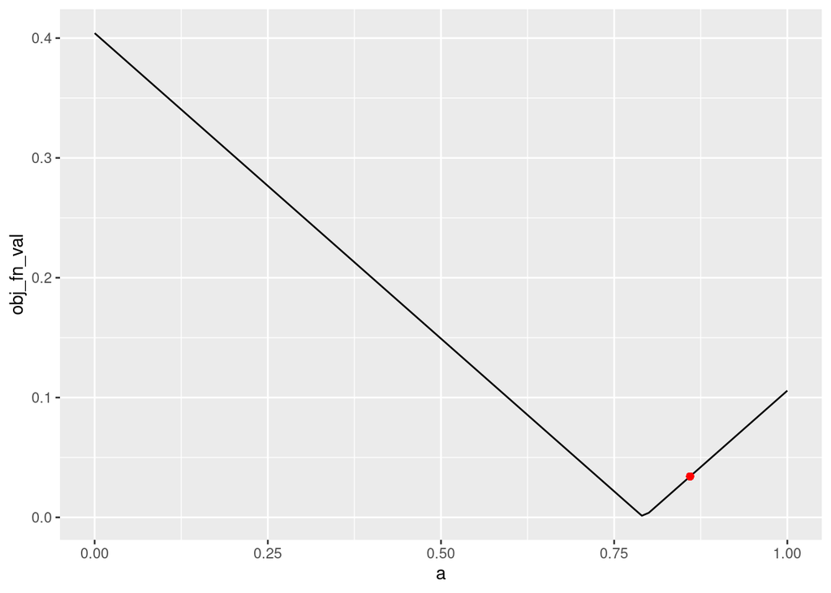

```r
# ...


# Let's implement a simplex-like search for only 'a'
mpt_objective_function_for_only_a <- function(a) {
  mpt_objective_function(a = a, g = .4)
}


obj_fn_df <- data.frame(a = seq(0,1, .01),
                        obj_fn_val = mpt_objective_function_for_only_a(seq(0,1, .01))
                        )

start_a <- runif(n = 1, min = .1, max=.9)
cur_a = start_a

{
epsilon <- runif(n = 1, min = 0, max=0.05)

val_cur <- mpt_objective_function_for_only_a(cur_a)
val_left <- mpt_objective_function_for_only_a(cur_a-epsilon)
val_right <- mpt_objective_function_for_only_a(cur_a+epsilon)
if (val_left < val_cur) {
  cur_a <- cur_a-epsilon
  val_cur <- val_left
} else { # assumption that if not val_left < val_cur, then val_right < val_cur
  cur_a <- cur_a+epsilon
  val_cur <- val_right
}

obj_fn_df %>% ggplot(aes(a, obj_fn_val)) + geom_line() + geom_point(aes(x = cur_a, y = val_cur), color = "red")
}
```

```r
# Let's implement an objective function ('discrepancy function')


# Let's implement a simplex-like search

# df <- NULL
#
# x <- function() {
#   df <<- 1
# }
```